# Week 5: Armed conflict and mortality exploration

Author

Milly Wu

## Starting question and observation units

The quiz plan was to examine changes in recorded armed conflicts over time, after checking the meaning of a row, missing data, and repeated records. That question guides the first part of this analysis. The remaining sections examine mortality distributions, missingness, and differences across regions and prior-year conflict groups to prepare for descriptive tables and later models.

The raw conflict file has event-level records for **1999-2018**, including explicit no-event country-year placeholders. The final dataset has one row per **country and outcome year**, with 186 countries over 2000-2019. Its conflict variable refers to the previous year. The two time axes therefore differ by one year; there is no contemporaneous 2019 conflict count in these files.

A conflict may have several event rows and occur in more than one country. The main trend counts each distinct `conflict_id` once per source year. A second series counts IDs that reach at least 25 deaths within at least one country-conflict-year. Neither series is a count of new conflict onsets.

## Data checks before counting

| Check | Count |
| --- | --- |
| Raw conflict rows | 208,531 |
| Real event records | 205,835 |
| No-event placeholders | 2,696 |
| Repeated rows across all supplied fields | 179,141 |
| Missing country/year keys | 0 |
| Incomplete real event records | 0 |
| Duplicate final country-year keys | 0 |

There are 179,141 rows whose available fields repeat an earlier row. The extract has only `conflict_id`, `iso`, `year`, and `best`; it has no unique event ID, date, or location identifier. Identical reduced rows can represent different events, so they were not removed. This limits what can be concluded about event counts and death totals without the fuller source data.

Every source year contains 186 country codes. No country/year key is missing, and all real events have death counts. The final dataset has no duplicate country-year keys. The comparison report records 32 passed checks and exact agreement with the two archived Week 3 outputs.

## How recorded conflicts change over time

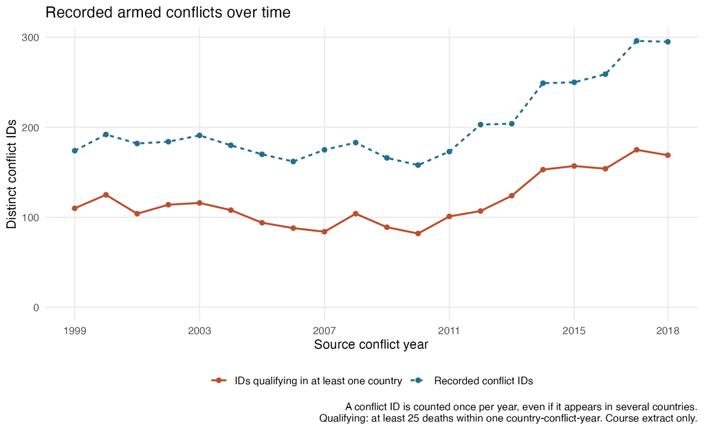

Recorded IDs number **174 in 1999** and **295 in 2018**. The lowest count is 158 in 2010; the highest is 296 in 2017. The pattern is not a steady rise: the series falls through much of the 2000s before increasing in the 2010s. The qualifying-conflict count is lower because some recorded IDs do not reach the threshold within any one country-year.

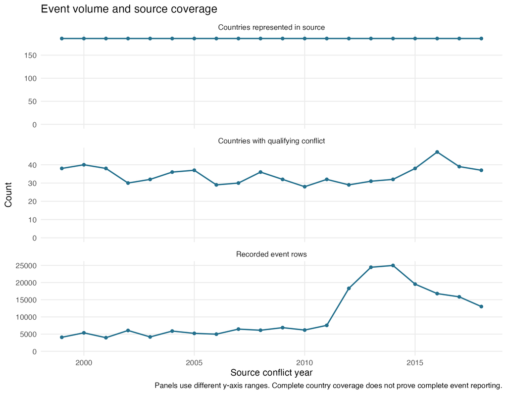

Event rows rise from 7548 in 2011 to 18307 in 2012, then peak at 24967 in 2014. The number of countries with qualifying conflict peaks in 2016, a different year. Conflict IDs, event records, and affected countries measure different aspects of the data. Stable country coverage does not rule out changes in reporting intensity or coding. This extract alone cannot explain the jump in event rows.

| Source year | Recorded IDs | Qualifying IDs | Event rows | Affected countries |
| --- | --- | --- | --- | --- |
| 1999 | 174 | 110 | 4077 | 38 |
| 2000 | 192 | 125 | 5373 | 40 |
| 2001 | 182 | 104 | 3961 | 38 |
| 2002 | 184 | 114 | 6060 | 30 |
| 2003 | 191 | 116 | 4179 | 32 |
| 2004 | 180 | 108 | 5885 | 36 |
| 2005 | 170 | 94 | 5217 | 37 |
| 2006 | 162 | 88 | 4985 | 29 |
| 2007 | 175 | 84 | 6456 | 30 |
| 2008 | 183 | 104 | 6125 | 36 |
| 2009 | 166 | 89 | 6882 | 32 |
| 2010 | 158 | 82 | 6181 | 28 |
| 2011 | 173 | 101 | 7548 | 32 |
| 2012 | 203 | 107 | 18307 | 29 |
| 2013 | 204 | 124 | 24448 | 31 |
| 2014 | 249 | 153 | 24967 | 32 |
| 2015 | 250 | 157 | 19539 | 38 |
| 2016 | 259 | 154 | 16786 | 47 |
| 2017 | 296 | 175 | 15843 | 39 |
| 2018 | 295 | 169 | 13016 | 37 |

## Missing mortality and covariate data

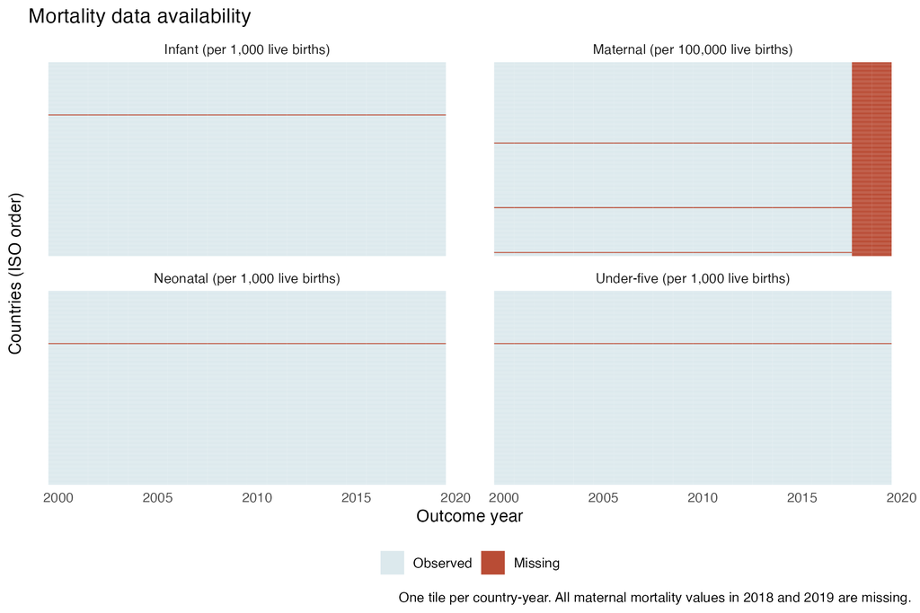

|  | Variable | Missing rows | Missing (%) |
| --- | --- | --- | --- |
| 6 | maternal_mortality | 426 | 11.45 |
| 7 | infant_mortality | 20 | 0.54 |
| 8 | neonatal_mortality | 20 | 0.54 |
| 9 | under5_mortality | 20 | 0.54 |
| 13 | gdp_1000 | 62 | 1.67 |
| 15 | pop_dens | 20 | 0.54 |
| 16 | urban | 20 | 0.54 |
| 18 | male_edu | 20 | 0.54 |
| 19 | temp | 20 | 0.54 |
| 20 | rainfall_1000 | 20 | 0.54 |

All maternal mortality values in 2018 and 2019 are absent. Those two years account for 372 of the 426 missing maternal observations; 54 are missing earlier. The other mortality measures each have 20 missing observations. Available-case summaries are calculated separately for each variable. Missing values are not imputed, and rows are not removed merely because another variable is missing. A later model needs an explicit outcome-specific sample definition.

## Distributions and unusual values

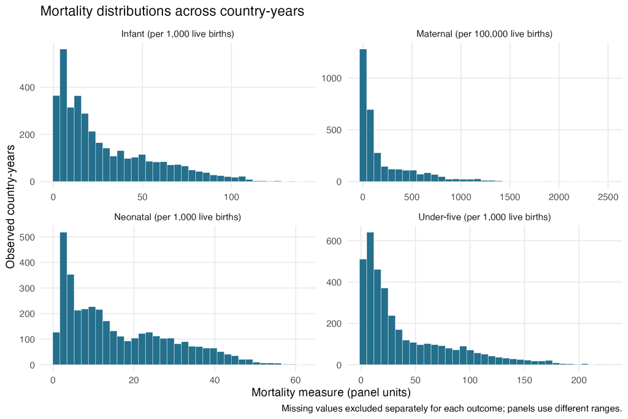

Maternal mortality has a median of 66 and a mean of 210.6 per 100,000 live births, with a long upper tail. The maximum is 2480. These high values are retained: they match the source file, and an extreme value alone is not evidence of a coding error. The child mortality outcomes are also right-skewed.

| Variable | Observed N | Median | Q1 | Q3 | Minimum | Maximum |
| --- | --- | --- | --- | --- | --- | --- |
| maternal_mortality | 3294 | 66.00 | 17.00 | 299.75 | 2.00 | 2480.00 |
| infant_mortality | 3700 | 18.90 | 7.60 | 44.52 | 1.60 | 138.10 |
| neonatal_mortality | 3700 | 12.10 | 4.90 | 25.32 | 0.80 | 60.90 |
| under5_mortality | 3700 | 22.20 | 9.00 | 61.33 | 2.00 | 224.90 |
| gdp_1000 | 3658 | 4.07 | 1.24 | 13.15 | 0.11 | 123.68 |
| pop_dens | 3700 | 27.52 | 14.79 | 40.72 | 0.00 | 99.86 |
| urban | 3700 | 30.25 | 17.29 | 41.66 | 0.10 | 93.41 |
| age_dep | 3720 | 55.51 | 47.94 | 77.11 | 16.17 | 111.48 |
| male_edu | 3700 | 8.37 | 5.90 | 10.85 | 1.07 | 14.44 |
| temp | 3700 | 21.96 | 12.93 | 25.87 | -2.40 | 29.68 |
| rainfall_1000 | 3700 | 1.01 | 0.59 | 1.69 | 0.02 | 4.71 |

All observed mortality values are nonnegative, and neonatal mortality does not exceed infant mortality, which does not exceed under-five mortality. No observed numeric value is infinite. GDP and the other covariates remain in their supplied scales; their full unit definitions should be confirmed before interpretation. The complete summaries also include means and standard deviations in continuous_summary.csv.

## Mortality over time

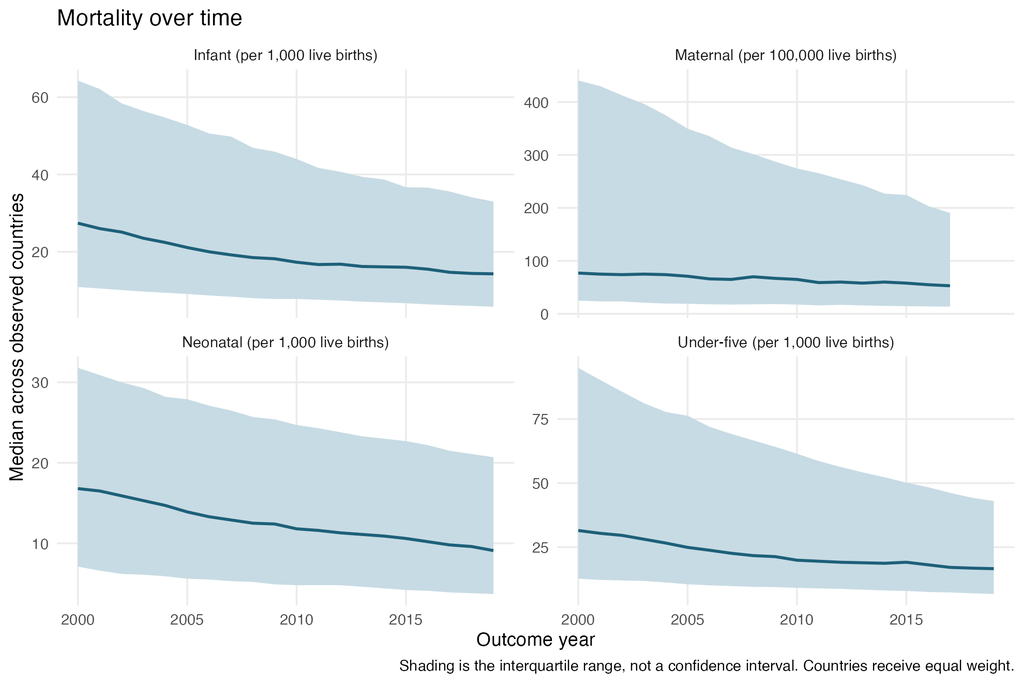

Median mortality declines over the available years for all four outcomes. The maternal series ends in 2017 because the later values are missing. Shading shows variation across countries, not uncertainty around an estimated mean. These are unweighted country summaries. They do not estimate a birth-weighted world mortality rate, and available-country counts are saved alongside each annual summary.

## Conflict exposure and region

| Region | Countries | Country-years | Prior-conflict years | Prior conflict (%) | Maternal observed N | Maternal median |
| --- | --- | --- | --- | --- | --- | --- |
| Africa | 54 | 1080 | 316 | 29.3 | 972 | 491 |
| Americas | 35 | 700 | 81 | 11.6 | 612 | 72 |
| Asia | 46 | 920 | 259 | 28.2 | 828 | 41 |
| Europe | 40 | 800 | 32 | 4.0 | 702 | 8 |
| Oceania | 11 | 220 | 3 | 1.4 | 180 | 80 |

Africa and Asia contribute most exposed country-years. Oceania contributes only three, so its exposed group is too small for a stable descriptive comparison. Country counts and country-year counts must not be used interchangeably.

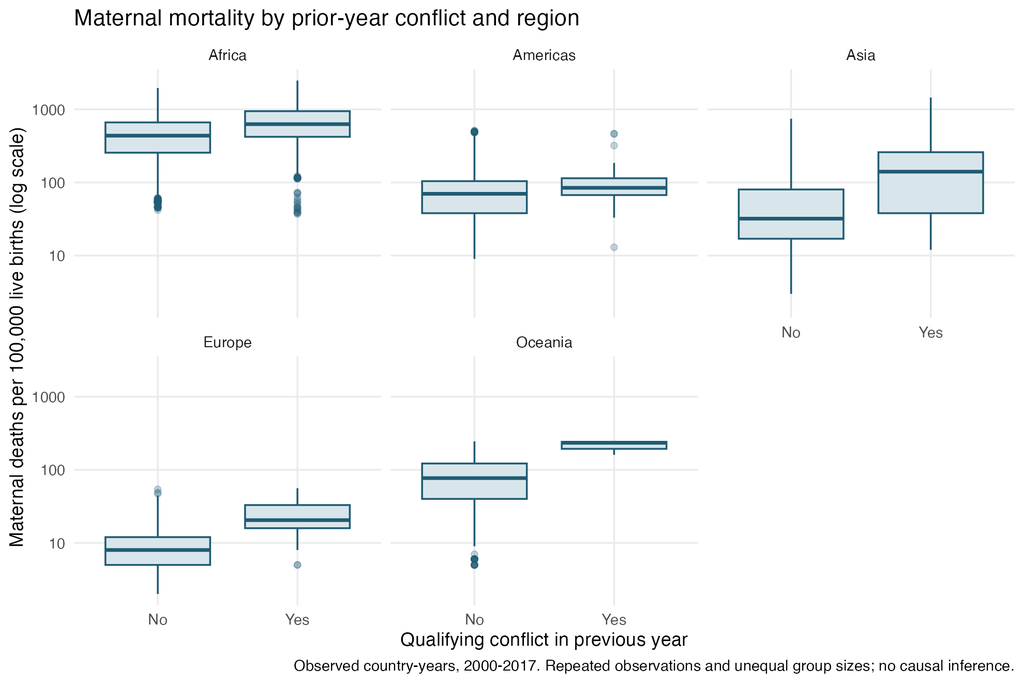

Across all observed maternal country-years, the median is 251 in the prior-conflict group and 52 in the no-prior-conflict group, per 100,000 live births. The groups differ in geography, calendar time, and other characteristics. Observations from the same country are correlated. These descriptive differences do not identify an effect of conflict, and no independent-observation significance tests are used here.

## What this suggests for the next analysis

Use country-year as the observation unit, label the one-year conflict lag, and report missing counts with each measure. Limit maternal trend displays to years with observed data. For later regression, define the sample by outcome and account for repeated measurements within countries, time trends, and the study’s confounding assumptions. Before interpreting the increase in event rows, seek source documentation on reporting and event identifiers.

The raw data and Week 3 outputs were not corrected because the comparison found no discrepancies. No causal model is fitted in this EDA.